# Risk Factor Analysis

## Outcome Variable

**Outcome Variable:** y_rate_haz

## Predictor Variables

**Intervention Variable:** vagbrth

**Adjustment Set:**

- arm
- sex
- W_mage
- meducyrs
- feducyrs
- hhwealth_quart
- W_mhtcm
- W_nrooms
- brthmon
- W_parity
- delta_W_mage
- delta_meducyrs
- delta_feducyrs
- delta_hhwealth_quart
- delta_W_mhtcm
- delta_W_nrooms
- delta_brthmon
- delta_W_parity

## Stratifying Variables

The analysis was stratified on these variable(s):

- agecat
- studyid
- country

## Data Summary

| agecat | studyid | country | vagbrth | n_cell | n |
| --- | --- | --- | --- | --- | --- |
| 0-3 months | ki1017093b-PROVIDE | BANGLADESH | 0 | 148 | 634 |
| 0-3 months | ki1017093b-PROVIDE | BANGLADESH | 1 | 486 | 634 |
| 0-3 months | ki1017093c-NIH-Crypto | BANGLADESH | 0 | 193 | 469 |
| 0-3 months | ki1017093c-NIH-Crypto | BANGLADESH | 1 | 276 | 469 |
| 0-3 months | kiGH5241-JiVitA-3 | BANGLADESH | 0 | 852 | 20010 |
| 0-3 months | kiGH5241-JiVitA-3 | BANGLADESH | 1 | 19158 | 20010 |
| 0-3 months | kiGH5241-JiVitA-4 | BANGLADESH | 0 | 100 | 1805 |
| 0-3 months | kiGH5241-JiVitA-4 | BANGLADESH | 1 | 1705 | 1805 |
| 0-3 months | ki1119695-PROBIT | BELARUS | 0 | 1424 | 12745 |
| 0-3 months | ki1119695-PROBIT | BELARUS | 1 | 11321 | 12745 |
| 0-3 months | ki1000108-CMC-V-BCS-2002 | INDIA | 0 | 10 | 87 |
| 0-3 months | ki1000108-CMC-V-BCS-2002 | INDIA | 1 | 77 | 87 |
| 0-3 months | ki1000108-IRC | INDIA | 0 | 66 | 377 |
| 0-3 months | ki1000108-IRC | INDIA | 1 | 311 | 377 |
| 0-3 months | ki1126311-ZVITAMBO | ZIMBABWE | 0 | 683 | 7802 |
| 0-3 months | ki1126311-ZVITAMBO | ZIMBABWE | 1 | 7119 | 7802 |
| 3-6 months | ki1017093b-PROVIDE | BANGLADESH | 0 | 133 | 574 |
| 3-6 months | ki1017093b-PROVIDE | BANGLADESH | 1 | 441 | 574 |
| 3-6 months | ki1017093c-NIH-Crypto | BANGLADESH | 0 | 182 | 443 |
| 3-6 months | ki1017093c-NIH-Crypto | BANGLADESH | 1 | 261 | 443 |
| 3-6 months | kiGH5241-JiVitA-3 | BANGLADESH | 0 | 769 | 12550 |
| 3-6 months | kiGH5241-JiVitA-3 | BANGLADESH | 1 | 11781 | 12550 |
| 3-6 months | kiGH5241-JiVitA-4 | BANGLADESH | 0 | 128 | 1762 |
| 3-6 months | kiGH5241-JiVitA-4 | BANGLADESH | 1 | 1634 | 1762 |
| 3-6 months | ki1119695-PROBIT | BELARUS | 0 | 1473 | 13309 |
| 3-6 months | ki1119695-PROBIT | BELARUS | 1 | 11836 | 13309 |
| 3-6 months | ki1000108-CMC-V-BCS-2002 | INDIA | 0 | 21 | 307 |
| 3-6 months | ki1000108-CMC-V-BCS-2002 | INDIA | 1 | 286 | 307 |
| 3-6 months | ki1000108-IRC | INDIA | 0 | 67 | 397 |
| 3-6 months | ki1000108-IRC | INDIA | 1 | 330 | 397 |
| 3-6 months | ki1066203-TanzaniaChild2 | TANZANIA, UNITED REPUBLIC OF | 0 | 159 | 1641 |
| 3-6 months | ki1066203-TanzaniaChild2 | TANZANIA, UNITED REPUBLIC OF | 1 | 1482 | 1641 |
| 3-6 months | ki1126311-ZVITAMBO | ZIMBABWE | 0 | 509 | 5842 |
| 3-6 months | ki1126311-ZVITAMBO | ZIMBABWE | 1 | 5333 | 5842 |
| 6-12 months | ki1017093b-PROVIDE | BANGLADESH | 0 | 121 | 545 |
| 6-12 months | ki1017093b-PROVIDE | BANGLADESH | 1 | 424 | 545 |
| 6-12 months | ki1017093c-NIH-Crypto | BANGLADESH | 0 | 176 | 420 |
| 6-12 months | ki1017093c-NIH-Crypto | BANGLADESH | 1 | 244 | 420 |
| 6-12 months | kiGH5241-JiVitA-3 | BANGLADESH | 0 | 591 | 9804 |
| 6-12 months | kiGH5241-JiVitA-3 | BANGLADESH | 1 | 9213 | 9804 |
| 6-12 months | kiGH5241-JiVitA-4 | BANGLADESH | 0 | 237 | 2808 |
| 6-12 months | kiGH5241-JiVitA-4 | BANGLADESH | 1 | 2571 | 2808 |
| 6-12 months | ki1119695-PROBIT | BELARUS | 0 | 1444 | 12896 |
| 6-12 months | ki1119695-PROBIT | BELARUS | 1 | 11452 | 12896 |
| 6-12 months | ki1000108-CMC-V-BCS-2002 | INDIA | 0 | 22 | 323 |
| 6-12 months | ki1000108-CMC-V-BCS-2002 | INDIA | 1 | 301 | 323 |
| 6-12 months | ki1000108-IRC | INDIA | 0 | 68 | 400 |
| 6-12 months | ki1000108-IRC | INDIA | 1 | 332 | 400 |
| 6-12 months | ki1066203-TanzaniaChild2 | TANZANIA, UNITED REPUBLIC OF | 0 | 102 | 1065 |
| 6-12 months | ki1066203-TanzaniaChild2 | TANZANIA, UNITED REPUBLIC OF | 1 | 963 | 1065 |
| 6-12 months | ki1126311-ZVITAMBO | ZIMBABWE | 0 | 369 | 4533 |
| 6-12 months | ki1126311-ZVITAMBO | ZIMBABWE | 1 | 4164 | 4533 |
| 12-24 months | ki1017093b-PROVIDE | BANGLADESH | 0 | 101 | 458 |
| 12-24 months | ki1017093b-PROVIDE | BANGLADESH | 1 | 357 | 458 |
| 12-24 months | ki1017093c-NIH-Crypto | BANGLADESH | 0 | 94 | 241 |
| 12-24 months | ki1017093c-NIH-Crypto | BANGLADESH | 1 | 147 | 241 |
| 12-24 months | kiGH5241-JiVitA-3 | BANGLADESH | 0 | 262 | 4628 |
| 12-24 months | kiGH5241-JiVitA-3 | BANGLADESH | 1 | 4366 | 4628 |
| 12-24 months | kiGH5241-JiVitA-4 | BANGLADESH | 0 | 257 | 3115 |
| 12-24 months | kiGH5241-JiVitA-4 | BANGLADESH | 1 | 2858 | 3115 |
| 12-24 months | ki1119695-PROBIT | BELARUS | 0 | 298 | 2533 |
| 12-24 months | ki1119695-PROBIT | BELARUS | 1 | 2235 | 2533 |
| 12-24 months | ki1000108-CMC-V-BCS-2002 | INDIA | 0 | 23 | 324 |
| 12-24 months | ki1000108-CMC-V-BCS-2002 | INDIA | 1 | 301 | 324 |
| 12-24 months | ki1000108-IRC | INDIA | 0 | 67 | 396 |
| 12-24 months | ki1000108-IRC | INDIA | 1 | 329 | 396 |
| 12-24 months | ki1066203-TanzaniaChild2 | TANZANIA, UNITED REPUBLIC OF | 0 | 1 | 2 |
| 12-24 months | ki1066203-TanzaniaChild2 | TANZANIA, UNITED REPUBLIC OF | 1 | 1 | 2 |
| 12-24 months | ki1126311-ZVITAMBO | ZIMBABWE | 0 | 20 | 297 |
| 12-24 months | ki1126311-ZVITAMBO | ZIMBABWE | 1 | 277 | 297 |

The following strata were considered:

- agecat: 0-3 months, studyid: ki1000108-CMC-V-BCS-2002, country: INDIA
- agecat: 0-3 months, studyid: ki1000108-IRC, country: INDIA
- agecat: 0-3 months, studyid: ki1017093b-PROVIDE, country: BANGLADESH
- agecat: 0-3 months, studyid: ki1017093c-NIH-Crypto, country: BANGLADESH
- agecat: 0-3 months, studyid: ki1119695-PROBIT, country: BELARUS
- agecat: 0-3 months, studyid: ki1126311-ZVITAMBO, country: ZIMBABWE
- agecat: 0-3 months, studyid: kiGH5241-JiVitA-3, country: BANGLADESH
- agecat: 0-3 months, studyid: kiGH5241-JiVitA-4, country: BANGLADESH
- agecat: 12-24 months, studyid: ki1000108-CMC-V-BCS-2002, country: INDIA
- agecat: 12-24 months, studyid: ki1000108-IRC, country: INDIA
- agecat: 12-24 months, studyid: ki1017093b-PROVIDE, country: BANGLADESH
- agecat: 12-24 months, studyid: ki1017093c-NIH-Crypto, country: BANGLADESH
- agecat: 12-24 months, studyid: ki1066203-TanzaniaChild2, country: TANZANIA, UNITED REPUBLIC OF
- agecat: 12-24 months, studyid: ki1119695-PROBIT, country: BELARUS
- agecat: 12-24 months, studyid: ki1126311-ZVITAMBO, country: ZIMBABWE
- agecat: 12-24 months, studyid: kiGH5241-JiVitA-3, country: BANGLADESH
- agecat: 12-24 months, studyid: kiGH5241-JiVitA-4, country: BANGLADESH
- agecat: 3-6 months, studyid: ki1000108-CMC-V-BCS-2002, country: INDIA
- agecat: 3-6 months, studyid: ki1000108-IRC, country: INDIA
- agecat: 3-6 months, studyid: ki1017093b-PROVIDE, country: BANGLADESH
- agecat: 3-6 months, studyid: ki1017093c-NIH-Crypto, country: BANGLADESH
- agecat: 3-6 months, studyid: ki1066203-TanzaniaChild2, country: TANZANIA, UNITED REPUBLIC OF
- agecat: 3-6 months, studyid: ki1119695-PROBIT, country: BELARUS
- agecat: 3-6 months, studyid: ki1126311-ZVITAMBO, country: ZIMBABWE
- agecat: 3-6 months, studyid: kiGH5241-JiVitA-3, country: BANGLADESH
- agecat: 3-6 months, studyid: kiGH5241-JiVitA-4, country: BANGLADESH
- agecat: 6-12 months, studyid: ki1000108-CMC-V-BCS-2002, country: INDIA
- agecat: 6-12 months, studyid: ki1000108-IRC, country: INDIA
- agecat: 6-12 months, studyid: ki1017093b-PROVIDE, country: BANGLADESH
- agecat: 6-12 months, studyid: ki1017093c-NIH-Crypto, country: BANGLADESH
- agecat: 6-12 months, studyid: ki1066203-TanzaniaChild2, country: TANZANIA, UNITED REPUBLIC OF
- agecat: 6-12 months, studyid: ki1119695-PROBIT, country: BELARUS
- agecat: 6-12 months, studyid: ki1126311-ZVITAMBO, country: ZIMBABWE
- agecat: 6-12 months, studyid: kiGH5241-JiVitA-3, country: BANGLADESH
- agecat: 6-12 months, studyid: kiGH5241-JiVitA-4, country: BANGLADESH

### Dropped Strata

Some strata were dropped due to rare outcomes:

- agecat: 12-24 months, studyid: ki1066203-TanzaniaChild2, country: TANZANIA, UNITED REPUBLIC OF

## Methods Detail

We’re interested in the causal parameters $E[Y_a]$ for all values of $a \in \mathcal{A}$. These parameters represent the mean outcome if, possibly contrary to fact, we intervened to set all units to have $A=a$. Under the randomization and positivity assumptions, these are identified by the statistical parameters $\psi_a=E_W[E_{Y|A,W}(Y|A=a,W)]$. In addition, we’re interested in the mean of $Y$, $E[Y]$ under no intervention (the observed mean). We will estimate these parameters by using SuperLearner to fit the relevant likelihood factors – $E_{Y|A,W}(Y|A=a,W)$ and $p(A=a|W)$, and then updating our likelihood fit using a joint TMLE.

For unadjusted analyses ($W=\{\}$), initial likelihoods were estimated using Lrnr_glm to estimate the simple $E(Y|A)$ and Lrnr_mean to estimate $p(A)$. For adjusted analyses, a small library containing Lrnr_glmnet, Lrnr_xgboost, and Lrnr_mean was used.

# Results Detail

## Results Plots

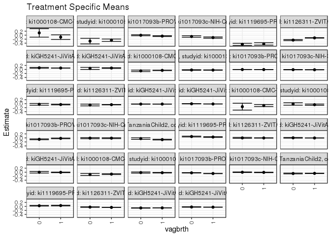

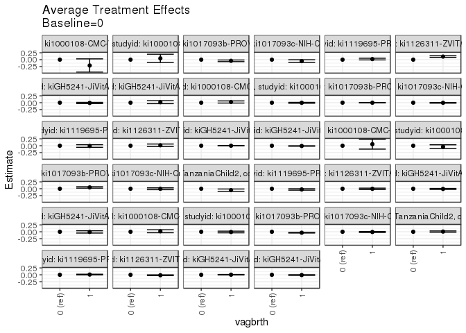

## Results Table

### Parameter: TSM

| agecat | studyid | country | intervention_level | baseline_level | estimate | ci_lower | ci_upper |
| --- | --- | --- | --- | --- | --- | --- | --- |
| 0-3 months | ki1000108-CMC-V-BCS-2002 | INDIA | 0 | NA | 0.1143379 | -0.0983840 | 0.3270597 |
| 0-3 months | ki1000108-CMC-V-BCS-2002 | INDIA | 1 | NA | -0.0980496 | -0.2136600 | 0.0175609 |
| 0-3 months | ki1000108-IRC | INDIA | 0 | NA | -0.2969431 | -0.4374931 | -0.1563932 |
| 0-3 months | ki1000108-IRC | INDIA | 1 | NA | -0.2504907 | -0.3090180 | -0.1919634 |
| 0-3 months | ki1017093b-PROVIDE | BANGLADESH | 0 | NA | -0.0042560 | -0.0298326 | 0.0213206 |
| 0-3 months | ki1017093b-PROVIDE | BANGLADESH | 1 | NA | -0.0464420 | -0.0649757 | -0.0279083 |
| 0-3 months | ki1017093c-NIH-Crypto | BANGLADESH | 0 | NA | -0.0673390 | -0.1051141 | -0.0295639 |
| 0-3 months | ki1017093c-NIH-Crypto | BANGLADESH | 1 | NA | -0.1198687 | -0.1518281 | -0.0879093 |
| 0-3 months | ki1119695-PROBIT | BELARUS | 0 | NA | -0.4581064 | -0.5117011 | -0.4045116 |
| 0-3 months | ki1119695-PROBIT | BELARUS | 1 | NA | -0.4369647 | -0.4972339 | -0.3766956 |
| 0-3 months | ki1126311-ZVITAMBO | ZIMBABWE | 0 | NA | -0.2468354 | -0.2741317 | -0.2195391 |
| 0-3 months | ki1126311-ZVITAMBO | ZIMBABWE | 1 | NA | -0.1351131 | -0.1460155 | -0.1242106 |
| 0-3 months | kiGH5241-JiVitA-3 | BANGLADESH | 0 | NA | 0.0799251 | 0.0584859 | 0.1013643 |
| 0-3 months | kiGH5241-JiVitA-3 | BANGLADESH | 1 | NA | 0.0703080 | 0.0652253 | 0.0753908 |
| 0-3 months | kiGH5241-JiVitA-4 | BANGLADESH | 0 | NA | 0.0506409 | -0.0014989 | 0.1027807 |
| 0-3 months | kiGH5241-JiVitA-4 | BANGLADESH | 1 | NA | 0.0697457 | 0.0543736 | 0.0851177 |
| 3-6 months | ki1000108-CMC-V-BCS-2002 | INDIA | 0 | NA | -0.1498299 | -0.3218283 | 0.0221686 |
| 3-6 months | ki1000108-CMC-V-BCS-2002 | INDIA | 1 | NA | -0.0941530 | -0.1436696 | -0.0446364 |
| 3-6 months | ki1000108-IRC | INDIA | 0 | NA | -0.0154603 | -0.0762797 | 0.0453592 |
| 3-6 months | ki1000108-IRC | INDIA | 1 | NA | -0.0509386 | -0.0832506 | -0.0186266 |
| 3-6 months | ki1017093b-PROVIDE | BANGLADESH | 0 | NA | -0.0711907 | -0.0920573 | -0.0503242 |
| 3-6 months | ki1017093b-PROVIDE | BANGLADESH | 1 | NA | -0.0229326 | -0.0401506 | -0.0057146 |
| 3-6 months | ki1017093c-NIH-Crypto | BANGLADESH | 0 | NA | -0.0110097 | -0.0381959 | 0.0161765 |
| 3-6 months | ki1017093c-NIH-Crypto | BANGLADESH | 1 | NA | -0.0119068 | -0.0341360 | 0.0103223 |
| 3-6 months | ki1066203-TanzaniaChild2 | TANZANIA, UNITED REPUBLIC OF | 0 | NA | -0.0340145 | -0.0730697 | 0.0050408 |
| 3-6 months | ki1066203-TanzaniaChild2 | TANZANIA, UNITED REPUBLIC OF | 1 | NA | -0.0852031 | -0.1024699 | -0.0679362 |
| 3-6 months | ki1119695-PROBIT | BELARUS | 0 | NA | 0.0697767 | 0.0478638 | 0.0916896 |
| 3-6 months | ki1119695-PROBIT | BELARUS | 1 | NA | 0.0441779 | 0.0235082 | 0.0648476 |
| 3-6 months | ki1126311-ZVITAMBO | ZIMBABWE | 0 | NA | 0.0000364 | -0.0241358 | 0.0242085 |
| 3-6 months | ki1126311-ZVITAMBO | ZIMBABWE | 1 | NA | -0.0027129 | -0.0125210 | 0.0070952 |
| 3-6 months | kiGH5241-JiVitA-3 | BANGLADESH | 0 | NA | 0.0038211 | -0.0144382 | 0.0220805 |
| 3-6 months | kiGH5241-JiVitA-3 | BANGLADESH | 1 | NA | -0.0035789 | -0.0086137 | 0.0014560 |
| 3-6 months | kiGH5241-JiVitA-4 | BANGLADESH | 0 | NA | -0.0049789 | -0.0444083 | 0.0344506 |
| 3-6 months | kiGH5241-JiVitA-4 | BANGLADESH | 1 | NA | -0.0098890 | -0.0242347 | 0.0044566 |
| 6-12 months | ki1000108-CMC-V-BCS-2002 | INDIA | 0 | NA | -0.1167907 | -0.1677095 | -0.0658720 |
| 6-12 months | ki1000108-CMC-V-BCS-2002 | INDIA | 1 | NA | -0.0978503 | -0.1192716 | -0.0764289 |
| 6-12 months | ki1000108-IRC | INDIA | 0 | NA | -0.0198661 | -0.0482311 | 0.0084988 |
| 6-12 months | ki1000108-IRC | INDIA | 1 | NA | -0.0276088 | -0.0414757 | -0.0137419 |
| 6-12 months | ki1017093b-PROVIDE | BANGLADESH | 0 | NA | -0.0338327 | -0.0436525 | -0.0240129 |
| 6-12 months | ki1017093b-PROVIDE | BANGLADESH | 1 | NA | -0.0676810 | -0.0750423 | -0.0603197 |
| 6-12 months | ki1017093c-NIH-Crypto | BANGLADESH | 0 | NA | -0.0037811 | -0.0180448 | 0.0104825 |
| 6-12 months | ki1017093c-NIH-Crypto | BANGLADESH | 1 | NA | -0.0115482 | -0.0243934 | 0.0012969 |
| 6-12 months | ki1066203-TanzaniaChild2 | TANZANIA, UNITED REPUBLIC OF | 0 | NA | -0.0673698 | -0.0880305 | -0.0467091 |
| 6-12 months | ki1066203-TanzaniaChild2 | TANZANIA, UNITED REPUBLIC OF | 1 | NA | -0.0602208 | -0.0698430 | -0.0505987 |
| 6-12 months | ki1119695-PROBIT | BELARUS | 0 | NA | 0.0339290 | 0.0179091 | 0.0499489 |
| 6-12 months | ki1119695-PROBIT | BELARUS | 1 | NA | 0.0428312 | 0.0260073 | 0.0596552 |
| 6-12 months | ki1126311-ZVITAMBO | ZIMBABWE | 0 | NA | -0.0338661 | -0.0474889 | -0.0202432 |
| 6-12 months | ki1126311-ZVITAMBO | ZIMBABWE | 1 | NA | -0.0497380 | -0.0545633 | -0.0449127 |
| 6-12 months | kiGH5241-JiVitA-3 | BANGLADESH | 0 | NA | -0.0783319 | -0.0875263 | -0.0691375 |
| 6-12 months | kiGH5241-JiVitA-3 | BANGLADESH | 1 | NA | -0.0748801 | -0.0777987 | -0.0719616 |
| 6-12 months | kiGH5241-JiVitA-4 | BANGLADESH | 0 | NA | -0.0292915 | -0.0405900 | -0.0179930 |
| 6-12 months | kiGH5241-JiVitA-4 | BANGLADESH | 1 | NA | -0.0380907 | -0.0428309 | -0.0333505 |
| 12-24 months | ki1000108-CMC-V-BCS-2002 | INDIA | 0 | NA | -0.0724498 | -0.1097453 | -0.0351543 |
| 12-24 months | ki1000108-CMC-V-BCS-2002 | INDIA | 1 | NA | -0.0471995 | -0.0575704 | -0.0368287 |
| 12-24 months | ki1000108-IRC | INDIA | 0 | NA | -0.0282588 | -0.0429378 | -0.0135797 |
| 12-24 months | ki1000108-IRC | INDIA | 1 | NA | -0.0323298 | -0.0400365 | -0.0246231 |
| 12-24 months | ki1017093b-PROVIDE | BANGLADESH | 0 | NA | -0.0058096 | -0.0109278 | -0.0006914 |
| 12-24 months | ki1017093b-PROVIDE | BANGLADESH | 1 | NA | -0.0074822 | -0.0115145 | -0.0034499 |
| 12-24 months | ki1017093c-NIH-Crypto | BANGLADESH | 0 | NA | -0.0122832 | -0.0225680 | -0.0019984 |
| 12-24 months | ki1017093c-NIH-Crypto | BANGLADESH | 1 | NA | -0.0166308 | -0.0234145 | -0.0098471 |
| 12-24 months | ki1119695-PROBIT | BELARUS | 0 | NA | -0.0329829 | -0.0771166 | 0.0111508 |
| 12-24 months | ki1119695-PROBIT | BELARUS | 1 | NA | -0.0435155 | -0.0614295 | -0.0256014 |
| 12-24 months | ki1126311-ZVITAMBO | ZIMBABWE | 0 | NA | -0.0673960 | -0.1113486 | -0.0234433 |
| 12-24 months | ki1126311-ZVITAMBO | ZIMBABWE | 1 | NA | -0.0505627 | -0.0599885 | -0.0411370 |
| 12-24 months | kiGH5241-JiVitA-3 | BANGLADESH | 0 | NA | -0.0193287 | -0.0243458 | -0.0143115 |
| 12-24 months | kiGH5241-JiVitA-3 | BANGLADESH | 1 | NA | -0.0190149 | -0.0208801 | -0.0171496 |
| 12-24 months | kiGH5241-JiVitA-4 | BANGLADESH | 0 | NA | -0.0052553 | -0.0129559 | 0.0024454 |
| 12-24 months | kiGH5241-JiVitA-4 | BANGLADESH | 1 | NA | -0.0145690 | -0.0166950 | -0.0124431 |

### Parameter: E(Y)

[output not shown]

### Parameter: ATE

| agecat | studyid | country | intervention_level | baseline_level | estimate | ci_lower | ci_upper |
| --- | --- | --- | --- | --- | --- | --- | --- |
| 0-3 months | ki1000108-CMC-V-BCS-2002 | INDIA | 0 | 0 | 0.0000000 | 0.0000000 | 0.0000000 |
| 0-3 months | ki1000108-CMC-V-BCS-2002 | INDIA | 1 | 0 | -0.2123874 | -0.4532005 | 0.0284257 |
| 0-3 months | ki1000108-IRC | INDIA | 0 | 0 | 0.0000000 | 0.0000000 | 0.0000000 |
| 0-3 months | ki1000108-IRC | INDIA | 1 | 0 | 0.0464524 | -0.1041589 | 0.1970637 |
| 0-3 months | ki1017093b-PROVIDE | BANGLADESH | 0 | 0 | 0.0000000 | 0.0000000 | 0.0000000 |
| 0-3 months | ki1017093b-PROVIDE | BANGLADESH | 1 | 0 | -0.0421860 | -0.0713959 | -0.0129762 |
| 0-3 months | ki1017093c-NIH-Crypto | BANGLADESH | 0 | 0 | 0.0000000 | 0.0000000 | 0.0000000 |
| 0-3 months | ki1017093c-NIH-Crypto | BANGLADESH | 1 | 0 | -0.0525297 | -0.1018972 | -0.0031623 |
| 0-3 months | ki1119695-PROBIT | BELARUS | 0 | 0 | 0.0000000 | 0.0000000 | 0.0000000 |
| 0-3 months | ki1119695-PROBIT | BELARUS | 1 | 0 | 0.0211416 | -0.0097041 | 0.0519873 |
| 0-3 months | ki1126311-ZVITAMBO | ZIMBABWE | 0 | 0 | 0.0000000 | 0.0000000 | 0.0000000 |
| 0-3 months | ki1126311-ZVITAMBO | ZIMBABWE | 1 | 0 | 0.1117224 | 0.0824310 | 0.1410137 |
| 0-3 months | kiGH5241-JiVitA-3 | BANGLADESH | 0 | 0 | 0.0000000 | 0.0000000 | 0.0000000 |
| 0-3 months | kiGH5241-JiVitA-3 | BANGLADESH | 1 | 0 | -0.0096171 | -0.0316119 | 0.0123778 |
| 0-3 months | kiGH5241-JiVitA-4 | BANGLADESH | 0 | 0 | 0.0000000 | 0.0000000 | 0.0000000 |
| 0-3 months | kiGH5241-JiVitA-4 | BANGLADESH | 1 | 0 | 0.0191048 | -0.0354381 | 0.0736476 |
| 3-6 months | ki1000108-CMC-V-BCS-2002 | INDIA | 0 | 0 | 0.0000000 | 0.0000000 | 0.0000000 |
| 3-6 months | ki1000108-CMC-V-BCS-2002 | INDIA | 1 | 0 | 0.0556769 | -0.1233027 | 0.2346565 |
| 3-6 months | ki1000108-IRC | INDIA | 0 | 0 | 0.0000000 | 0.0000000 | 0.0000000 |
| 3-6 months | ki1000108-IRC | INDIA | 1 | 0 | -0.0354784 | -0.1036079 | 0.0326511 |
| 3-6 months | ki1017093b-PROVIDE | BANGLADESH | 0 | 0 | 0.0000000 | 0.0000000 | 0.0000000 |
| 3-6 months | ki1017093b-PROVIDE | BANGLADESH | 1 | 0 | 0.0482581 | 0.0228960 | 0.0736202 |
| 3-6 months | ki1017093c-NIH-Crypto | BANGLADESH | 0 | 0 | 0.0000000 | 0.0000000 | 0.0000000 |
| 3-6 months | ki1017093c-NIH-Crypto | BANGLADESH | 1 | 0 | -0.0008971 | -0.0334967 | 0.0317025 |
| 3-6 months | ki1066203-TanzaniaChild2 | TANZANIA, UNITED REPUBLIC OF | 0 | 0 | 0.0000000 | 0.0000000 | 0.0000000 |
| 3-6 months | ki1066203-TanzaniaChild2 | TANZANIA, UNITED REPUBLIC OF | 1 | 0 | -0.0511886 | -0.0933027 | -0.0090745 |
| 3-6 months | ki1119695-PROBIT | BELARUS | 0 | 0 | 0.0000000 | 0.0000000 | 0.0000000 |
| 3-6 months | ki1119695-PROBIT | BELARUS | 1 | 0 | -0.0255988 | -0.0516038 | 0.0004063 |
| 3-6 months | ki1126311-ZVITAMBO | ZIMBABWE | 0 | 0 | 0.0000000 | 0.0000000 | 0.0000000 |
| 3-6 months | ki1126311-ZVITAMBO | ZIMBABWE | 1 | 0 | -0.0027492 | -0.0286992 | 0.0232007 |
| 3-6 months | kiGH5241-JiVitA-3 | BANGLADESH | 0 | 0 | 0.0000000 | 0.0000000 | 0.0000000 |
| 3-6 months | kiGH5241-JiVitA-3 | BANGLADESH | 1 | 0 | -0.0074000 | -0.0263690 | 0.0115689 |
| 3-6 months | kiGH5241-JiVitA-4 | BANGLADESH | 0 | 0 | 0.0000000 | 0.0000000 | 0.0000000 |
| 3-6 months | kiGH5241-JiVitA-4 | BANGLADESH | 1 | 0 | -0.0049102 | -0.0463614 | 0.0365411 |
| 6-12 months | ki1000108-CMC-V-BCS-2002 | INDIA | 0 | 0 | 0.0000000 | 0.0000000 | 0.0000000 |
| 6-12 months | ki1000108-CMC-V-BCS-2002 | INDIA | 1 | 0 | 0.0189405 | -0.0358329 | 0.0737138 |
| 6-12 months | ki1000108-IRC | INDIA | 0 | 0 | 0.0000000 | 0.0000000 | 0.0000000 |
| 6-12 months | ki1000108-IRC | INDIA | 1 | 0 | -0.0077427 | -0.0388449 | 0.0233595 |
| 6-12 months | ki1017093b-PROVIDE | BANGLADESH | 0 | 0 | 0.0000000 | 0.0000000 | 0.0000000 |
| 6-12 months | ki1017093b-PROVIDE | BANGLADESH | 1 | 0 | -0.0338483 | -0.0461138 | -0.0215827 |
| 6-12 months | ki1017093c-NIH-Crypto | BANGLADESH | 0 | 0 | 0.0000000 | 0.0000000 | 0.0000000 |
| 6-12 months | ki1017093c-NIH-Crypto | BANGLADESH | 1 | 0 | -0.0077671 | -0.0271067 | 0.0115726 |
| 6-12 months | ki1066203-TanzaniaChild2 | TANZANIA, UNITED REPUBLIC OF | 0 | 0 | 0.0000000 | 0.0000000 | 0.0000000 |
| 6-12 months | ki1066203-TanzaniaChild2 | TANZANIA, UNITED REPUBLIC OF | 1 | 0 | 0.0071490 | -0.0151973 | 0.0294952 |
| 6-12 months | ki1119695-PROBIT | BELARUS | 0 | 0 | 0.0000000 | 0.0000000 | 0.0000000 |
| 6-12 months | ki1119695-PROBIT | BELARUS | 1 | 0 | 0.0089022 | -0.0040557 | 0.0218601 |
| 6-12 months | ki1126311-ZVITAMBO | ZIMBABWE | 0 | 0 | 0.0000000 | 0.0000000 | 0.0000000 |
| 6-12 months | ki1126311-ZVITAMBO | ZIMBABWE | 1 | 0 | -0.0158719 | -0.0302495 | -0.0014944 |
| 6-12 months | kiGH5241-JiVitA-3 | BANGLADESH | 0 | 0 | 0.0000000 | 0.0000000 | 0.0000000 |
| 6-12 months | kiGH5241-JiVitA-3 | BANGLADESH | 1 | 0 | 0.0034518 | -0.0063860 | 0.0132895 |
| 6-12 months | kiGH5241-JiVitA-4 | BANGLADESH | 0 | 0 | 0.0000000 | 0.0000000 | 0.0000000 |
| 6-12 months | kiGH5241-JiVitA-4 | BANGLADESH | 1 | 0 | -0.0087992 | -0.0209550 | 0.0033567 |
| 12-24 months | ki1000108-CMC-V-BCS-2002 | INDIA | 0 | 0 | 0.0000000 | 0.0000000 | 0.0000000 |
| 12-24 months | ki1000108-CMC-V-BCS-2002 | INDIA | 1 | 0 | 0.0252502 | -0.0134155 | 0.0639159 |
| 12-24 months | ki1000108-IRC | INDIA | 0 | 0 | 0.0000000 | 0.0000000 | 0.0000000 |
| 12-24 months | ki1000108-IRC | INDIA | 1 | 0 | -0.0040710 | -0.0204545 | 0.0123125 |
| 12-24 months | ki1017093b-PROVIDE | BANGLADESH | 0 | 0 | 0.0000000 | 0.0000000 | 0.0000000 |
| 12-24 months | ki1017093b-PROVIDE | BANGLADESH | 1 | 0 | -0.0016726 | -0.0080619 | 0.0047168 |
| 12-24 months | ki1017093c-NIH-Crypto | BANGLADESH | 0 | 0 | 0.0000000 | 0.0000000 | 0.0000000 |
| 12-24 months | ki1017093c-NIH-Crypto | BANGLADESH | 1 | 0 | -0.0043476 | -0.0166679 | 0.0079728 |
| 12-24 months | ki1119695-PROBIT | BELARUS | 0 | 0 | 0.0000000 | 0.0000000 | 0.0000000 |
| 12-24 months | ki1119695-PROBIT | BELARUS | 1 | 0 | -0.0105325 | -0.0574554 | 0.0363904 |
| 12-24 months | ki1126311-ZVITAMBO | ZIMBABWE | 0 | 0 | 0.0000000 | 0.0000000 | 0.0000000 |
| 12-24 months | ki1126311-ZVITAMBO | ZIMBABWE | 1 | 0 | 0.0168332 | -0.0280199 | 0.0616864 |
| 12-24 months | kiGH5241-JiVitA-3 | BANGLADESH | 0 | 0 | 0.0000000 | 0.0000000 | 0.0000000 |
| 12-24 months | kiGH5241-JiVitA-3 | BANGLADESH | 1 | 0 | 0.0003138 | -0.0049224 | 0.0055501 |
| 12-24 months | kiGH5241-JiVitA-4 | BANGLADESH | 0 | 0 | 0.0000000 | 0.0000000 | 0.0000000 |
| 12-24 months | kiGH5241-JiVitA-4 | BANGLADESH | 1 | 0 | -0.0093138 | -0.0172209 | -0.0014066 |